# Modelos de marcação e recaptura: delineamento robusto

Leonardo Wedekin e Paulo Inácio Prado (http://ecologia.ib.usp.br/bie5703)

- Arquivo em pdf
- Arquivo em markdown (para executar os comandos no R studio)

## Preparação

Vamos usar o *RMark*, que é um pacote do R para usar o programa [MARK](http://www.phidot.org/software/mark). Siga as instruções do [site do RMark](http://www.phidot.org/software/mark/rmark/) para instalação.

Com o RMark instalado, abra o R e carregue-o:

```r
library(RMark)
```

Usaremos dados de marcação e recaptura de albatrozes (*Phoebastria immutabilis*) no atol de Midway. Foi usado o [delineamento robusto de Pollock](http://www.phidot.org/software/mark/docs/book/pdf/chap15.pdf), com quatro ocasiões primárias com duas ocasiões secundárias cada. [Aqui](http://ecologia.ib.usp.br/bie5703/lib/exe/fetch.php?media=roteiros:exercicio_9b_albatroz_robusto.pdf) há mais informações sobre este caso de estudo.

Os dados estão no formato nativo do MARK (*.inp*). Use os comandos abaixo para importá-lo para o R:

```r
## Link dos dados na página da disciplina
url <- "http://ecologia.ib.usp.br/bie5703/lib/exe/fetch.php?media=roteiros:albatroz.inp"
## Importa arquivo inp
## use.comments=TRUE usa os rótulos das linhas (id dos indivíduos)
alb.raw <- convert.inp(url, use.comments=TRUE)
```

## Ajuste dos modelos

### Processamento dos dados

O primeiro passo é usar a função `process.data` para criar um objeto com as informações que o Mark precisa para ajustar o modelo. Uma delas é o tipo de modelo, que é indicado no argumento `model`.

Vamos usar o modelo robusto para populações fechadas, cuja a sigla no RMark é “Robust” [^1].

Para esta classe de modelos indique os intervalos de tempo com um vetor em que os zeros indicam os momentos em que a população é considerada fechada. Os elementos diferentes de zero indicam a duração de cada intervalo. Neste exercício os intervalos entre as ocasiões são todos de um ano, com duas instâncias secundárias cada, o que representamos com um vetor de valores $1$ e $0$. Note que omitimos o último valor, que é sempre não zero, por definição.

```r
## Vetor de intervalos (zero = fechamento)
ti <- c(0, 1, 0, 1, 0, 1, 0)
## Processa os dados
alb <- process.data(data=alb.raw, model="Robust", time.intervals=ti)
```

O objeto resultante é uma lista, na qual podemos conferir o número de ocasiões primárias e secundárias, por exemplo:

```r
## N de ocasiões primárias
alb$nocc
```

```
## [1] 4
```

```r
## N de ocasiões secundárias em cada primária
alb$nocc.secondary
```

```
## [1] 2 2 2 2
```

### Ajuste dos modelos

Para ajustar os modelos, crie listas que especificam a fórmula de cada termo. No modelo `Robust` os nomes parâmetros são:

- `S` : probabilidade de sobrevivência aparente entre capturas ($S$),
- `p` : probabilidade de recaptura ($c$),
- `GammaPrime` : probabilidade de permanecer não amostrável entre duas amostragens ($\gamma '$)
- `GammaDoublePrime` : probabilidade de tornar-se não amostrável entre duas amostragens (emigração temporária, $\gamma ''$)
- `f0` : número de indivíduos que não foram registrados.

Quando processamos os dados o RMark já cria algumas covariáveis para cada tipo de modelo. No modelo robusto há uma covariável chamada `session`, com um nível para cada ocasião primária de captura, e outra chama `time`, com um nível para cada intervalo entre seções primárias [^2].

Podemos então criar objetos com as fórmulas para diferentes combinações dessas covariáveis. Algumas possibilidades:

```r
## Fórmulas estatísticas para cada parâmetro do modelo
## formula para expressar um parâmetro constante
f.dot <- list(formula=~1)
## formula para expressar um parametro que varia em funcao das ocasiões primarias
f.occ <- list(formula=~-1+session)
## formula para expressar um parametro que varia a cada ano
f.time <- list(formula=~-1+time)
## formula para expressar os parâmetro fixos em zero
f.zero <- list(formula=~1, fixed=0)
```

Para indicar que dois parâmetros devem ser iguais, acrescente à lista `share=TRUE` [^3]:

```r
## Fórmulas estatísticas para parametros relacionados iguais
## (usa-se para fazer
## GammaPrime = GammaDoublePrime e  c = p)
## formula para expressar dois parâmetros relacionados constantes
f.dot.s <- list(formula=~1, share=TRUE)
## formula para expressar que os parametros variam em funcao das ocasiões primarias
f.occ.s <- list(formula=~-1+session, share=TRUE)
## formula para expressar parametros que variam a cada ano
f.time.s <- list(formula=~-1+time, share=TRUE)
## formula para expressar parametros que variam entre ocasioes secundárias
## Para os parametros de captura/recaptura
f.time2.s <- list(formula=~-1+session:time, share=TRUE)
```

E usamos a função `mark` para fazer os ajustes, usando os objetos com as fórmulas [^4]:

```r
alb1 <- mark(alb, model.parameters=
                 list(S=f.time, GammaDoublePrime=f.time, GammaPrime=f.time,
                      p=f.time2.s, f0=f.occ),
               adjust=TRUE, delete=TRUE)
```

```
##
## Note: only 17 parameters counted of 20 specified parameters
##
## AICc and parameter count have been adjusted upward
```

```r
alb2 <- mark(alb, model.parameters=
                 list(S=f.time, GammaDoublePrime=f.time.s,
                      p=f.time2.s, f0=f.occ),
               adjust=TRUE, delete=TRUE)
```

```
##
## Note: only 16 parameters counted of 18 specified parameters
##
## AICc and parameter count have been adjusted upward
```

```r
alb3 <- mark(alb, model.parameters=
                 list(S=f.time, GammaDoublePrime=f.dot, GammaPrime=f.dot,
                      p=f.time2.s, f0=f.occ),
               adjust=TRUE, delete=TRUE)
alb4 <- mark(alb, model.parameters=
                 list(S=f.time, GammaDoublePrime=f.dot.s,
                      p=f.time2.s, f0=f.occ),
               adjust=TRUE, delete=TRUE)
```

```
##
## Note: only 14 parameters counted of 16 specified parameters
##
## AICc and parameter count have been adjusted upward
```

```r
alb5 <- mark(alb, model.parameters=
                 list(S=f.time, GammaDoublePrime=f.zero, GammaPrime=f.zero,
                      p=f.time2.s, f0=f.occ),
               adjust=TRUE, delete=TRUE)
```

## Seleção de modelos

A função abaixo retorna a tabela de seleção de modelos:

```r
collect.models(lx=c("alb1", "alb2", "alb3", "alb4", "alb5"))
```

```
##                                                                                         model
## 3                 S(~-1 + time)Gamma''(~1)Gamma'(~1)p(~-1 + session:time)c()f0(~-1 + session)
## 4                   S(~-1 + time)Gamma''(~1)Gamma'()p(~-1 + session:time)c()f0(~-1 + session)
## 2           S(~-1 + time)Gamma''(~-1 + time)Gamma'()p(~-1 + session:time)c()f0(~-1 + session)
## 1 S(~-1 + time)Gamma''(~-1 + time)Gamma'(~-1 + time)p(~-1 + session:time)c()f0(~-1 + session)
## 5                 S(~-1 + time)Gamma''(~1)Gamma'(~1)p(~-1 + session:time)c()f0(~-1 + session)
##   npar      AICc  DeltaAICc       weight  Deviance
## 3   17 -103394.1    0.00000 9.999996e-01 -10978.60
## 4   16 -103363.6   30.44502 2.448768e-07 -10946.16
## 2   18 -103363.0   31.03527 1.822955e-07 -10949.57
## 1   20 -103312.9   81.14670 0.000000e+00 -10903.47
## 5   15 -102135.0 1259.01033 0.000000e+00  -9715.58
```

## Valores das estimativas

Os objetos dos modelos ajustados são uma lista com todo o output do Mark. Esta lista tem um elemento `results`, com os valores dos coeficientes e muito mais [^5]:

```r
names(alb3$results)
```

```
##  [1] "lnl"              "deviance"         "deviance.df"
##  [4] "npar"             "n"                "AICc"
##  [7] "beta"             "real"             "beta.vcv"
## [10] "derived"          "derived.vcv"      "covariate.values"
## [13] "singular"         "real.vcv"
```

Os coeficientes na escala da função de ligação estão no dataframe `beta` desta lista. Verifique estes valores para o modelo selecionado:

```r
alb3$results$beta
```

```
##                                estimate        se        lcl        ucl
## S:time1                       2.7013454 0.1430042  2.4210572  2.9816336
## S:time2                       3.0507085 0.3157963  2.4317478  3.6696692
## S:time3                       5.1540794 4.3368169 -3.3460820 13.6542410
## GammaDoublePrime:(Intercept) -0.6238005 0.0384584 -0.6991790 -0.5484221
## GammaPrime:(Intercept)       -1.4274901 0.1773241 -1.7750453 -1.0799349
## p:session1:time1              1.5319584 0.0820833  1.3710752  1.6928416
## p:session2:time1              2.1758733 0.0929144  1.9937611  2.3579855
## p:session3:time1              1.6228609 0.0714026  1.4829119  1.7628100
## p:session4:time1              0.6567630 0.0636023  0.5321024  0.7814236
## p:session1:time2             -0.2980582 0.0456685 -0.3875685 -0.2085478
## p:session2:time2             -0.1161154 0.0409353 -0.1963486 -0.0358822
## p:session3:time2             -0.1888297 0.0401244 -0.2674736 -0.1101858
## p:session4:time2             -0.6902731 0.0455340 -0.7795198 -0.6010265
## f0:session1                   5.4922205 0.1085585  5.2794459  5.7049951
## f0:session2                   4.9625994 0.1284605  4.7108169  5.2143820
## f0:session3                   5.5807827 0.0979316  5.3888368  5.7727286
## f0:session4                   6.6183185 0.0779788  6.4654800  6.7711570
```

Os coeficientes na escala original de probabilidades estão no dataframe `real`

```r
alb3$results$real
```

```
##                           estimate         se         lcl         ucl
## S g1 c1 c1 a0 t1         0.9371060  0.0084284   0.9184190   0.9517375
## S g1 c1 c1 a1 t2         0.9548131  0.0136250   0.9192164   0.9751484
## S g1 c1 c1 a2 t3         0.9942574  0.0247617   0.0340237   0.9999988
## Gamma'' g1 c1 c1 a0 t1   0.3489176  0.0087367   0.3319943   0.3662306
## Gamma' g1 c1 c1 a1 t2    0.1934901  0.0276717   0.1449160   0.2535183
## p g1 s1 t1               0.8222927  0.0119946   0.7975538   0.8445975
## p g1 s1 t2               0.4260322  0.0111673   0.4043028   0.4480512
## p g1 s2 t1               0.8980619  0.0085060   0.8801405   0.9135669
## p g1 s2 t2               0.4710037  0.0101994   0.4510700   0.4910304
## p g1 s3 t1               0.8351893  0.0098284   0.8150120   0.8535612
## p g1 s3 t2               0.4529323  0.0099422   0.4335274   0.4724814
## p g1 s4 t1               0.6585329  0.0143021   0.6299733   0.6859869
## p g1 s4 t2               0.3339723  0.0101283   0.3144234   0.3541089
## f0 g1 a0 s1 t0         242.7957400 26.3575330 196.3833900 300.1769700
## f0 g1 a0 s2 t0         142.9649400 18.3653440 111.2574000 183.7089000
## f0 g1 a0 s3 t0         265.2791500 25.9792030 219.0488300 321.2664100
## f0 g1 a0 s4 t0         748.6851300 58.3815800 642.7215600 872.1185900
##                        fixed    note
## S g1 c1 c1 a0 t1
## S g1 c1 c1 a1 t2
## S g1 c1 c1 a2 t3
## Gamma'' g1 c1 c1 a0 t1
## Gamma' g1 c1 c1 a1 t2
## p g1 s1 t1
## p g1 s1 t2
## p g1 s2 t1
## p g1 s2 t2
## p g1 s3 t1
## p g1 s3 t2
## p g1 s4 t1
## p g1 s4 t2
## f0 g1 a0 s1 t0
## f0 g1 a0 s2 t0
## f0 g1 a0 s3 t0
## f0 g1 a0 s4 t0
```

E os tamanhos populacionais a cada ocasião (um parâmetro derivado) estão no dataframe `derived`:

```r
alb3$results$derived
```

```
##   estimate       se      lcl      ucl
## 1 2384.796 26.35753 2338.383 2442.177
## 2 2659.965 18.36534 2628.257 2700.709
## 3 2947.279 25.97920 2901.049 3003.266
## 4 3293.685 58.38158 3187.722 3417.119
```

## Coda: refinando a seleção de modelos

As probabilidades de sobrevivência por ocasião estimadas pelo modelo selecionado são muito parecidas. Isso sugere que este parâmetro não varie entre ocasiões. Vamos incluir modelos com $S$ constante em nossa seleção para verificar:

```r
alb6 <- mark(alb, model.parameters=
                 list(S=f.dot, GammaDoublePrime=f.time, GammaPrime=f.time,
                      p=f.time2.s, f0=f.occ),
               adjust=TRUE, delete=TRUE)
alb7 <- mark(alb, model.parameters=
                 list(S=f.dot, GammaDoublePrime=f.time.s,
                      p=f.time2.s, f0=f.occ),
               adjust=TRUE, delete=TRUE)
alb8 <- mark(alb, model.parameters=
                 list(S=f.dot, GammaDoublePrime=f.dot, GammaPrime=f.dot,
                      p=f.time2.s, f0=f.occ),
               adjust=TRUE, delete=TRUE)
alb9 <- mark(alb, model.parameters=
                 list(S=f.dot, GammaDoublePrime=f.dot.s,
                      p=f.time2.s, f0=f.occ),
               adjust=TRUE, delete=TRUE)
alb10 <- mark(alb, model.parameters=
                 list(S=f.dot, GammaDoublePrime=f.zero, GammaPrime=f.zero,
                      p=f.time2.s, f0=f.occ),
               adjust=TRUE, delete=TRUE)
```

E repetimos a seleção de modelos:

```r
collect.models(lx=c("alb1", "alb2", "alb3", "alb4", "alb5",
                   "alb6", "alb7", "alb8", "alb9", "alb10"))
```

```
##                                                                                          model
## 3                  S(~-1 + time)Gamma''(~1)Gamma'(~1)p(~-1 + session:time)c()f0(~-1 + session)
## 6          S(~1)Gamma''(~-1 + time)Gamma'(~-1 + time)p(~-1 + session:time)c()f0(~-1 + session)
## 8                          S(~1)Gamma''(~1)Gamma'(~1)p(~-1 + session:time)c()f0(~-1 + session)
## 4                    S(~-1 + time)Gamma''(~1)Gamma'()p(~-1 + session:time)c()f0(~-1 + session)
## 2            S(~-1 + time)Gamma''(~-1 + time)Gamma'()p(~-1 + session:time)c()f0(~-1 + session)
## 7                    S(~1)Gamma''(~-1 + time)Gamma'()p(~-1 + session:time)c()f0(~-1 + session)
## 9                            S(~1)Gamma''(~1)Gamma'()p(~-1 + session:time)c()f0(~-1 + session)
## 1  S(~-1 + time)Gamma''(~-1 + time)Gamma'(~-1 + time)p(~-1 + session:time)c()f0(~-1 + session)
## 5                  S(~-1 + time)Gamma''(~1)Gamma'(~1)p(~-1 + session:time)c()f0(~-1 + session)
## 10                         S(~1)Gamma''(~1)Gamma'(~1)p(~-1 + session:time)c()f0(~-1 + session)
##    npar      AICc   DeltaAICc       weight  Deviance
## 3    17 -103394.1    0.000000 4.690098e-01 -10978.60
## 6    18 -103393.7    0.315273 4.006095e-01 -10980.29
## 8    15 -103391.5    2.560334 1.303804e-01 -10972.03
## 4    16 -103363.6   30.445021 1.148497e-07 -10946.16
## 2    18 -103363.0   31.035273 8.549841e-08 -10949.57
## 7    16 -103362.1   31.945021 5.425114e-08 -10944.65
## 9    14 -103353.6   40.415942 7.851844e-10 -10932.17
## 1    20 -103312.9   81.146700 0.000000e+00 -10903.47
## 5    15 -102135.0 1259.010334 0.000000e+00  -9715.58
## 10   13 -102033.3 1360.751842 0.000000e+00  -9609.83
```

E agora temos o empate com um modelo com $S$ constante mas parâmetros de migração variando com o tempo.

Será que os dois modelos plausíveis dão estimativas similares dos parâmetros de interesse? Vamos verificar.

O gráfico a seguir mostra os intervalos de confiança dos valores de $\gamma ''$ estimados para cada tempo pelo modelo 6 (barras pretas) e o intervalo de confiança da estimativa de $\gamma ''$ constante pelo modelo 3 (linhas azuis):

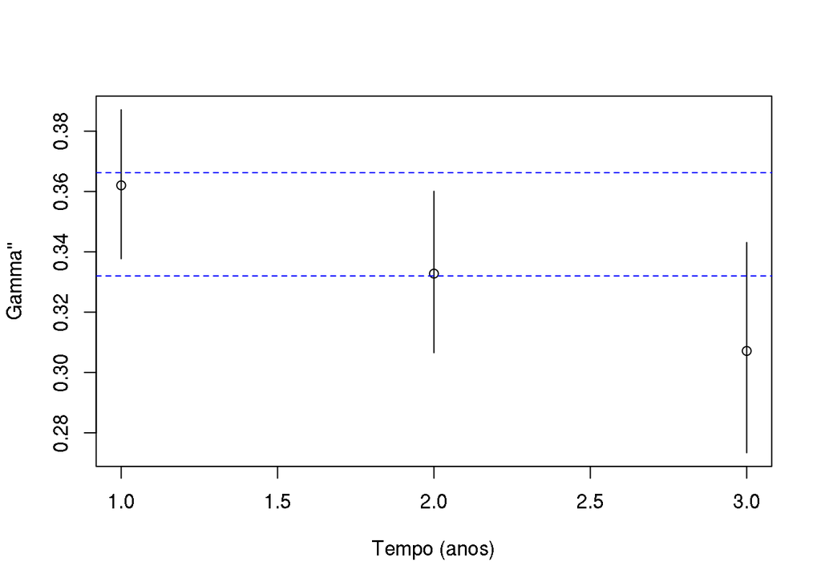

```r
plot(1:3, alb6$results$real[2:4,1], xlab="Tempo (anos)", ylab="Gamma''",
     ylim=range(alb6$results$real[2:4,3:4]))
segments(x0=1:3, y0=alb6$results$real[2:4,3], x1=1:3, y1=alb6$results$real[2:4,4])
abline(h=alb3$results$real[4,3:4], lty=2, col="blue")
```

A mesma comparação para o parâmetro $\gamma '$:

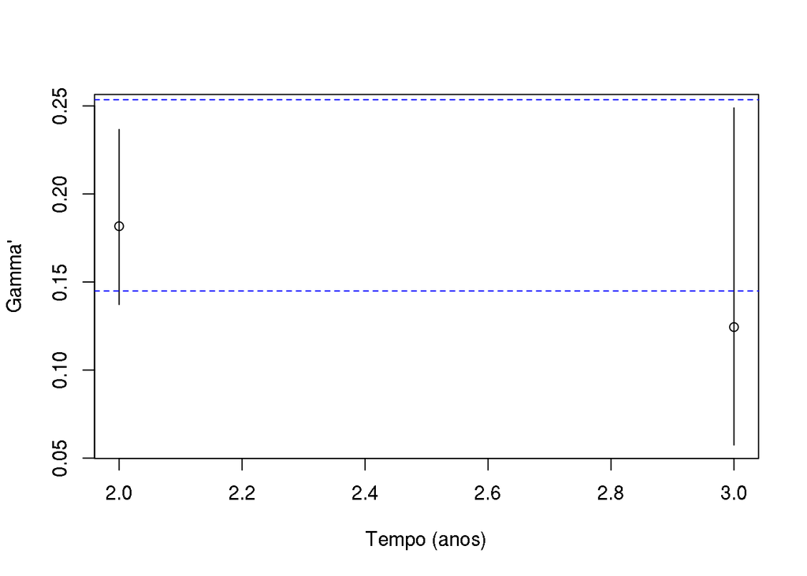

```r
plot(2:3, alb6$results$real[5:6,1], xlab="Tempo (anos)", ylab="Gamma'",
     ylim=range(alb6$results$real[5:6,3:4]))
segments(x0=2:3, y0=alb6$results$real[5:6,3], x1=2:3, y1=alb6$results$real[5:6,4])
abline(h=alb3$results$real[5,3:4], lty=2, col="blue")
```

E por fim comparamos as estimativas dos tamanhos populacionais

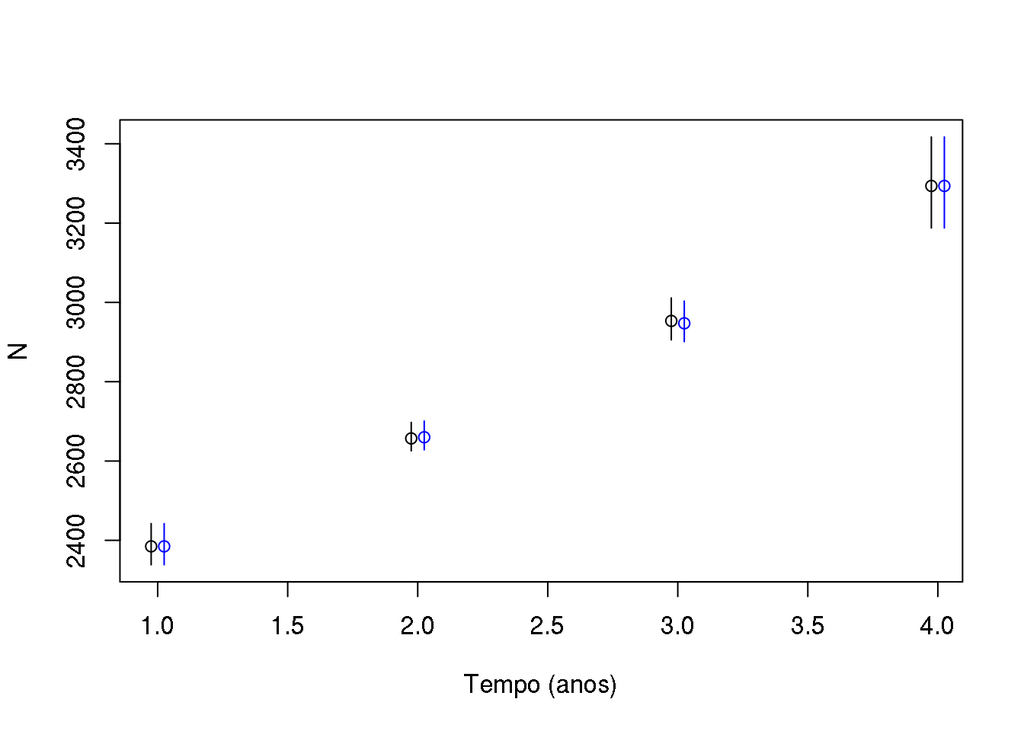

```r
tempo <- (1:4) -0.025
plot(tempo, alb6$results$derived[,1], xlab="Tempo (anos)", ylab="N",
     ylim=range(alb6$results$derived[,3:4]))
segments(x0=tempo, y0=alb6$results$derived[,3], x1=tempo, y1=alb6$results$derived[,4])
tempo <- tempo + 0.05
points(tempo, alb3$results$derived[,1], col="blue")
segments(x0=tempo, y0=alb3$results$derived[,3], x1=tempo, y1=alb3$results$derived[,4], col="blue")
```

## Para saber mais

- Para outro exemplo de ajuste do modelo robusto e outras funções úteis do RMark digite `?robust`
- Veja também o pacote Rcapture
[^1]: A lista de modelos implementados no RMark está no diretório onde o R instalou o pacote. Você pode consultá-lo lá ou no repositório de desenvolvimento do RMark: (https://github.com/jlaake/RMark/blob/master/RMark/inst/MarkModels.pdf).
[^2]: Para entender completamente isso estude o comando `make.design.data` e o objeto que ele cria, que é a uma lista de matrizes de delineamento do modelo. Se você entender este objeto saberá quais covariáveis estão disponíveis e como manipulá-las. Veja também o [apêndice sobre o RMark](http://www.phidot.org/software/mark/docs/book/pdf/app_3.pdf) no guia *online* do MARK.
[^3]: O RMark permite reduzir pares de alguns parâmetros a uma só estimativa. No caso do modelo robusto, pode-se substituir os parâmetros $\gamma '$ e $\gamma ''$ por um só (*random emigration model*); e também subsituir os parâmetros $p$ e $c$ por um único (modelo sem resposta comportamental à captura). Veja final da seção C.3 e exemplo na seção C.19 do apêndice sobre o RMark no guia *online* para mais detalhes.
[^4]: Use sempre os argumentos `delete=TRUE` para remover os arquivos temporários do Mark que o ajuste cria e `adjust=TRUE` para que o número de parâmetros seja verificado e ajustado, para o cálculo do AIC.
[^5]: Consulte o [apêndice sobre o RMark](http://www.phidot.org/software/mark/docs/book/pdf/app_3.pdf) no guia *online* do MARK.